# Target Markdown

21 January, 2026

# Target Markdown

Target Markdown is a powerful R Markdown interface for reproducible analysis pipelines, and the chapter at https://books.ropensci.org/targets/markdown.html walks through it in detail. This R Markdown report the example from the chapter. Try it out in both interactive and non-interactive modes, either by running the code chunks in different ways or setting the `tar_interactive` chunk option.

# Packages

The example requires `targets` version 0.5.0.9000 or above.

# Setup

Near the top of the document, you may wish to remove the `_targets_r` directory previously written by non-interactive runs of the report. Otherwise, your pipeline may contain superfluous targets.

```r
library(targets)
tar_unscript()
```

# Globals

We first define some global options/functions common to all targets.

```r
options(tidyverse.quiet = TRUE)
tar_option_set(packages = c("worcs"))
```

```
#> Establish _targets.R and _targets_r/globals/example-globals.R.
```

# Targets

Our first target borrows the `airquality` dataset built into base R.

```r
tar_target(raw_data, airquality)
```

```
#> Establish _targets.R and _targets_r/targets/raw-data.R.
```

Alternatively, you can use a `worcs` dataset, which you have saved in the `prepare_data.R` script by running running the following code, with either `closed_data()` or `open_data()`:

```r
open_data(airquality)
```

You may then load it like so:

```r
tar_target(worcs_data, load_data(to_envir = FALSE)$airquality)
```

```
#> Establish _targets.R and _targets_r/targets/worcs-data.R.
```

```r
list(
  tar_target(data, worcs_data[complete.cases(worcs_data), ]),
  tar_target(dens_data, density(data[["Ozone"]]))
)
```

```
#> Establish _targets.R and _targets_r/targets/downstream-targets.R.
```

Set the `tar_simple` chunk option to `TRUE` to define a single target with the command in the code chunk. The chunk below only contains `lm(Ozone ~ Wind + Temp, data)` in the source, but because `tar_simple` is `TRUE`, it is shorthand for `tar_target(name = fit, command = lm(Ozone ~ Wind + Temp, data))`. All other arguments to `tar_target()` are set to their default values (configurable with `tar_option_set()`).

```r
tar_target(fit, {
  lm(Ozone ~ Wind + Temp, data)
})
```

```
#> Define target fit from chunk code.
#> Establish _targets.R and _targets_r/targets/fit.R.
```

# Pipeline

If you ran all the `{targets}` chunks in non-interactive mode, then your R scripts are set up to run the pipeline.

```r
tar_make()
```

```
#> - The project is out-of-sync -- use `renv::status()` for details.
#> ✔ skipped pipeline [366ms, 5 skipped]
```

# Output

You can retrieve results from the `_targets/` data store using `tar_read()` or `tar_load()`.

```r
tar_read(fit)
```

```
#>
#> Call:
#> lm(formula = Ozone ~ Wind + Temp, data = data)
#>
#> Coefficients:
#> (Intercept)         Wind         Temp
#>     -67.322       -3.295        1.828
```

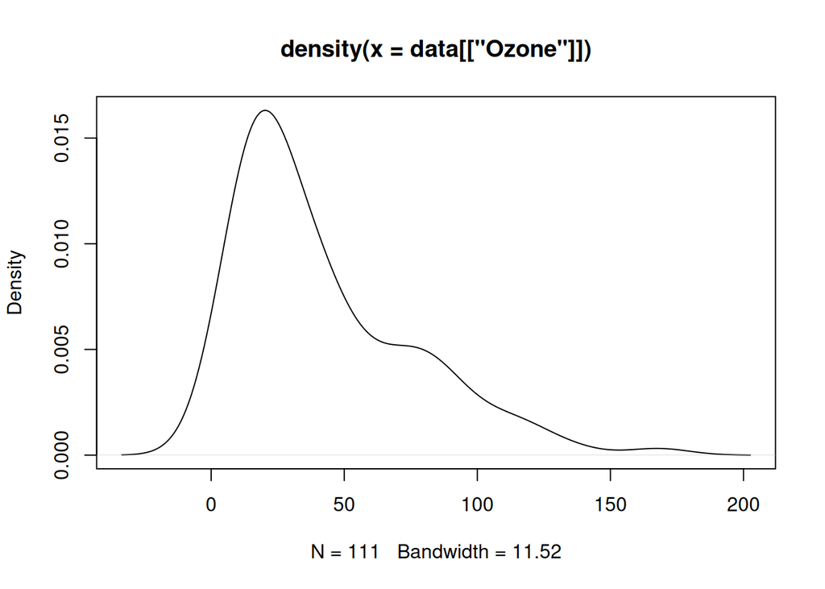

```r
plot(tar_read(dens_data))
```

The `targets` dependency graph helps your readers understand the steps of your pipeline at a high level.

```r
tar_visnetwork()
```

[output not shown]

At this point, you can go back and run `{targets}` chunks in interactive mode without interfering with the code or data of the non-interactive pipeline.